# Importing data from DSI Ponemah software

Andrew Stiegler

2020-03-02

This vignette will show an example of importing data collected with a DSI telemetry system running Ponemah software into R. The first step is to export data from the DSI telemetry system.

## Importing DSI data

First data must be exported from DSI’s Ponemah software.

To export data: with an experiment open, navigate to Experiment > Export Data. In this pop-up, select subjects to export, a timerange to export, and make sure to un-check “Pivot Compatible Sheets”

[figure not shown]

Screenshot of DSI Ponemah export screen

Select “Export” and an Excel file will be generated. To import that Excel file into R, utilize the DSI_export_to_dataframe function:

```r
exported_data <- DSI_export_to_dataframe('path_to_DSI_export')
```

A progress message will be displayed showing the current import status.

The output of the file is a dataframe:

```r
# Sample dataframe is included as sample_BP_data:
head(sample_BP_data)
```

```
#>       .id                Time TimesOnly ElapsedTime ElapsedTimeMin ElapsedTimeH
#> 1 1024071 2019-12-11 06:00:00  06:00:00           0              0   0.00000000
#> 2 1024071 2019-12-11 06:02:00  06:02:00         120              2   0.03333333
#> 3 1024071 2019-12-11 06:04:00  06:04:00         240              4   0.06666667
#> 4 1024071 2019-12-11 06:06:00  06:06:00         360              6   0.10000000
#> 5 1024071 2019-12-11 06:08:00  06:08:00         480              8   0.13333333
#> 6 1024071 2019-12-11 06:10:00  06:10:00         600             10   0.16666667
#>   ElapsedTimeD      SBP      DBP      MAP       HR     Temp     Activity
#> 1  0.000000000 110.6964 79.31778 89.77731 462.3699 34.33864 0.0009920789
#> 2  0.001388889 113.8884 82.62399 93.04547 524.8341 34.47567 0.0009920789
#> 3  0.002777778 107.9296 75.63431 86.39940 524.5176 34.66993 0.0009920789
#> 4  0.004166667 114.6534 81.35150 92.45214 484.7397 34.71082 0.0009920789
#> 5  0.005555556 109.3143 77.12240 87.85303 465.4864 34.67818 0.0009920789
#> 6  0.006944444 107.8810 75.94124 86.58783 474.8547 34.66138 0.0009920789
```

Where the .id column indicates the subject serial number, and the Time column is the real time of data acquisition. Several useful time columns are generated, including a column for time-of-day only, and elapsed time since acquisition started in several units. The rest of the telemetry parameters are named.

## After importing data

Several functions are available for data processing after import. The functions typical_day and circadian_avg both take the newly created dataframe as input.

To calculate a typical day:

```r
# In our sample dataset, room lights turn on at 6AM
sample_typical_day <- typical_day(data = sample_BP_data, lights_on = 6,
                                  progressbar = FALSE)
head(sample_typical_day)
```

```
#> # A tibble: 6 x 93
#>   Time  `1024071SBP` `1024071DBP` `1024071MAP` `1024071HR` `1024071Temp`
#>   <ITi>        <dbl>        <dbl>        <dbl>       <dbl>         <dbl>
#> 1 06:0~         122.         88.8         99.9        483.          34.6
#> 2 06:0~         118.         86.0         96.7        486.          34.6
#> 3 06:0~         113.         80.9         91.7        469.          34.7
#> 4 06:0~         117.         85.5         96.0        487.          34.8
#> 5 06:0~         123.         90.6        101.         505.          34.8
#> 6 06:1~         114.         80.2         91.5        458.          34.9
#> # ... with 87 more variables: `1024071Activity` <dbl>, `1024084SBP` <dbl>,
#> #   `1024084DBP` <dbl>, `1024084MAP` <dbl>, `1024084HR` <dbl>,
#> #   `1024084Temp` <dbl>, `1024084Activity` <dbl>, `1033468SBP` <dbl>,
#> #   `1033468DBP` <dbl>, `1033468MAP` <dbl>, `1033468HR` <dbl>,
#> #   `1033468Temp` <dbl>, `1033468Activity` <dbl>, `1033470SBP` <dbl>,
#> #   `1033470DBP` <dbl>, `1033470MAP` <dbl>, `1033470HR` <dbl>,
#> #   `1033470Temp` <dbl>, `1033470Activity` <dbl>, `1033478SBP` <dbl>,
#> #   `1033478DBP` <dbl>, `1033478MAP` <dbl>, `1033478HR` <dbl>,
#> #   `1033478Temp` <dbl>, `1033478Activity` <dbl>, `1033480SBP` <dbl>,
#> #   `1033480DBP` <dbl>, `1033480MAP` <dbl>, `1033480HR` <dbl>,
#> #   `1033480Temp` <dbl>, `1033480Activity` <dbl>, `1037725SBP` <dbl>,
#> #   `1037725DBP` <dbl>, `1037725MAP` <dbl>, `1037725HR` <dbl>,
#> #   `1037725Temp` <dbl>, `1037725Activity` <dbl>, `1037726SBP` <dbl>,
#> #   `1037726DBP` <dbl>, `1037726MAP` <dbl>, `1037726HR` <dbl>,
#> #   `1037726Temp` <dbl>, `1037726Activity` <dbl>, `1037727SBP` <dbl>,
#> #   `1037727DBP` <dbl>, `1037727MAP` <dbl>, `1037727HR` <dbl>,
#> #   `1037727Temp` <dbl>, `1037727Activity` <dbl>, `1037728SBP` <dbl>,
#> #   `1037728DBP` <dbl>, `1037728MAP` <dbl>, `1037728HR` <dbl>,
#> #   `1037728Temp` <dbl>, `1037728Activity` <dbl>, `1080808SBP` <dbl>,
#> #   `1080808DBP` <dbl>, `1080808MAP` <dbl>, `1080808HR` <dbl>,
#> #   `1080808Temp` <dbl>, `1080808Activity` <dbl>, `814438SBP` <dbl>,
#> #   `814438DBP` <dbl>, `814438MAP` <dbl>, `814438HR` <dbl>, `814438Temp` <dbl>,
#> #   `814438Activity` <dbl>, `848072SBP` <dbl>, `848072DBP` <dbl>,
#> #   `848072MAP` <dbl>, `848072HR` <dbl>, `848072Temp` <dbl>,
#> #   `848072Activity` <dbl>, `865262SBP` <dbl>, `865262DBP` <dbl>,
#> #   `865262MAP` <dbl>, `865262HR` <dbl>, `865262Temp` <dbl>,
#> #   `865262Activity` <dbl>, `967522SBP` <dbl>, `967522DBP` <dbl>,
#> #   `967522MAP` <dbl>, `967522HR` <dbl>, `967522Temp` <dbl>,
#> #   `967522Activity` <dbl>, LightsTime <dbl>, LightsOn <chr>
```

To calculate circadian averages:

```r
# In our sample dataset, room lights turn on at 6AM
sample_circadian_avg <- circadian_avg(data = sample_BP_data, lights_on = 6)
head(sample_circadian_avg[[1]])
```

```
#> # A tibble: 4 x 91
#>    Time `1024071SBP` `1024071DBP` `1024071MAP` `1024071Temp` `1024071HR`
#>   <int>        <dbl>        <dbl>        <dbl>         <dbl>       <dbl>
#> 1     1         128.         96.0         107.          536.        35.4
#> 2     2         129.         97.0         108.          556.        35.3
#> 3     3         128.         95.0         106.          521.        35.2
#> 4     4         129.         97.5         108.          539.        35.4
#> # ... with 85 more variables: `1024071Activity` <dbl>, `1024084SBP` <dbl>,
#> #   `1024084DBP` <dbl>, `1024084MAP` <dbl>, `1024084Temp` <dbl>,
#> #   `1024084HR` <dbl>, `1024084Activity` <dbl>, `1033468SBP` <dbl>,
#> #   `1033468DBP` <dbl>, `1033468MAP` <dbl>, `1033468Temp` <dbl>,
#> #   `1033468HR` <dbl>, `1033468Activity` <dbl>, `1033470SBP` <dbl>,
#> #   `1033470DBP` <dbl>, `1033470MAP` <dbl>, `1033470Temp` <dbl>,
#> #   `1033470HR` <dbl>, `1033470Activity` <dbl>, `1033478SBP` <dbl>,
#> #   `1033478DBP` <dbl>, `1033478MAP` <dbl>, `1033478Temp` <dbl>,
#> #   `1033478HR` <dbl>, `1033478Activity` <dbl>, `1033480SBP` <dbl>,
#> #   `1033480DBP` <dbl>, `1033480MAP` <dbl>, `1033480Temp` <dbl>,
#> #   `1033480HR` <dbl>, `1033480Activity` <dbl>, `1037725SBP` <dbl>,
#> #   `1037725DBP` <dbl>, `1037725MAP` <dbl>, `1037725Temp` <dbl>,
#> #   `1037725HR` <dbl>, `1037725Activity` <dbl>, `1037726SBP` <dbl>,
#> #   `1037726DBP` <dbl>, `1037726MAP` <dbl>, `1037726Temp` <dbl>,
#> #   `1037726HR` <dbl>, `1037726Activity` <dbl>, `1037727SBP` <dbl>,
#> #   `1037727DBP` <dbl>, `1037727MAP` <dbl>, `1037727Temp` <dbl>,
#> #   `1037727HR` <dbl>, `1037727Activity` <dbl>, `1037728SBP` <dbl>,
#> #   `1037728DBP` <dbl>, `1037728MAP` <dbl>, `1037728Temp` <dbl>,
#> #   `1037728HR` <dbl>, `1037728Activity` <dbl>, `1080808SBP` <dbl>,
#> #   `1080808DBP` <dbl>, `1080808MAP` <dbl>, `1080808Temp` <dbl>,
#> #   `1080808HR` <dbl>, `1080808Activity` <dbl>, `814438SBP` <dbl>,
#> #   `814438DBP` <dbl>, `814438MAP` <dbl>, `814438Temp` <dbl>, `814438HR` <dbl>,
#> #   `814438Activity` <dbl>, `848072SBP` <dbl>, `848072DBP` <dbl>,
#> #   `848072MAP` <dbl>, `848072Temp` <dbl>, `848072HR` <dbl>,
#> #   `848072Activity` <dbl>, `865262SBP` <dbl>, `865262DBP` <dbl>,
#> #   `865262MAP` <dbl>, `865262Temp` <dbl>, `865262HR` <dbl>,
#> #   `865262Activity` <dbl>, `967522SBP` <dbl>, `967522DBP` <dbl>,
#> #   `967522MAP` <dbl>, `967522Temp` <dbl>, `967522HR` <dbl>,
#> #   `967522Activity` <dbl>
```

Output from typical_day or circadian_avg can be plotted using ggplot:

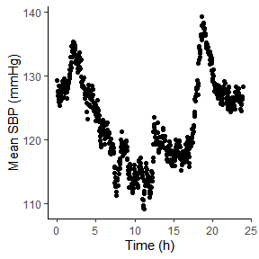

```r
# To plot typical SBP. first isolate SBP
sample_typical_sbp <- isolate_typical(data = sample_typical_day,
                                      parameter = "SBP")
# Create a column for mean SBP
sample_typical_sbp$mean <- sample_typical_sbp %>% dplyr::select(-Time) %>%
  rowMeans()

# Plot the mean against time in hours
ggplot(data = sample_typical_sbp)+
  geom_point(aes(x=Time/3600, y=mean))+
  ylab("Mean SBP (mmHg)")+
  xlab("Time (h)")+
  theme_classic()
```

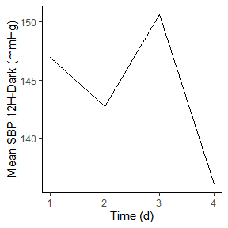

```r
# The second list element contains values when room is dark
sample_circadian_dark <- sample_circadian_avg[[2]]
# Isolate SBP
sample_circadian_dark_sbp <- isolate_typical(data = sample_circadian_dark,
                                             parameter = "SBP")
# Create a column for mean SBP
sample_circadian_dark_sbp$mean <- sample_circadian_dark %>%
  dplyr::select(-Time) %>% rowMeans()

# Plot the mean against time in days
ggplot(data = sample_circadian_dark_sbp)+
  geom_line(aes(x=Time, y=mean))+
  ylab("Mean SBP 12H-Dark (mmHg)")+
  xlab("Time (d)")+
  theme_classic()
```